# DDSAnalytics Attrition Analysis

Sam Arellano, Laurence Clinton, Karen Somes

April 15, 2019

## Introduction

According to the Society for Human Resource Management’s 2016 *Human Capital Benchmarking Report*, the average cost-per-hire for companies is $4,129 and the average time to fill a vacant position is 42 days. In addtittion to the recruitment and training costs high attrition, can also face increased opertional and reduced productivity as they lose trained and experienced employees.

Controlling attrition is without a doubt an area of opportunity for all companies, and one that can greatly impact long term success. The following report details the findings and recommendations of DDSAnalytics after having reviewed ACME Corporations turnover and HR data set.

Source: https://www.shrm.org/hr-today/trends-and-forecasting/research-and-surveys/Documents/2016-Human-Capital-Report.pdf

## The Data

The Dataset was comprised of 1470 observations each with 35 recorded variables. The data tracked a variety of factors possibly related to attrition. Based on the recorded summary data the attrition rate for the company is estimated to be 16.1% and the estimated average tenure is approximately 7 years, though it must be noted that based on a maximum recorded employee number of 2068 we can infer that there are at least 598 missing records. As such, the data will be treated as a sample of the overall population of company employees. While it is our goal to identify correlations between variables and create a model that accurately predicts attrition, because the dataset is comprised of observational data, no inferences regarding causation should be drawn from the results.

```r
#Read in the CaseStudy2-data.xlsx and set to Attrition data frame
#attrition <- read_excel("C:/git/CaseStudy2-master/CaseStudy2-data.xlsx")
attrition<-read_excel("/Users/ksomes/Downloads/CaseStudy2_2/CaseStudy2-data.xlsx")
```

## Excluded Variables Initial Analysis

Upon the initial overview of the dataset it was determined that the variables “Standard Hours”, “Over 18” and “Employee Count” would be excluded from exploratory data analysis as the value for those variables accross all observations is the same and would therefore impact the response variable for each observation with the same weight. The variable “Employee Number” was excluded from exploratory analysis because it is merely an identification variable and should have no effect on the response variable.

Exclusion of those variables resulted in a dataset with the following 30 explanatory variables. These variables would be used to determine their correlation to the response variable Attrition and to create a model for predicting Attrition.

| Nominal | Ordinal | Continous |
| --- | --- | --- |
| BusinessTravel | EnvironmentSatisfaction | Age |
| Department | JobInvolvement | DailyRate |
| Education | JobLevel | DistanceFromHome |
| EducationField | JobSatisfaction | HourlyRate |
| JobRole | PerformanceRating | MonthlyIncome |
| MaritalStatus | RelationshipSatisfaction | MonthlyRate |
| Gendter | StockOptionLevel | NumCompaniesWorked |
| Overtime | WorkLifeBalance | PercentSalaryHike |
|  |  | TotalWorkingYears |
|  |  | TrainingTimesLastYear |
|  |  | YearsAtCompany |
|  |  | YearsInCurrentRole |
|  |  | YearsSinceLastPromotion |
|  |  | YearsWithCurrManager |

```r
# Drop Employee Count, Standard Hours, Over 18, and Employee number
attrition <- attrition[,-c(9,10,22,27),drop=FALSE]
```

## Exploration of Probabilities: Naive Bayes

```r
#Run Model and get probabilities
library(e1071)
NB_All<- naiveBayes(Attrition~. ,data=dfcat, scale=T, type="prob")
#list probabilities
NB_All$tables
```

```
## $BusinessTravel
##      BusinessTravel
## Y     Non-Travel Travel_Frequently Travel_Rarely
##   No  0.11192214        0.16869424    0.71938362
##   Yes 0.05063291        0.29113924    0.65822785
##
## $Department
##      Department
## Y     Human Resources Research & Development      Sales
##   No       0.04136253             0.67153285 0.28710462
##   Yes      0.05063291             0.56118143 0.38818565
##
## $DistanceFromHome
##      DistanceFromHome
## Y      Under_10  10_to_20   Over_20
##   No  0.6545012 0.1995134 0.1459854
##   Yes 0.5611814 0.2320675 0.2067511
##
## $Education
##      Education
## Y       Bachelor Below_College    College     Doctor     Master
##   No  0.38361719    0.11273317 0.19302514 0.03487429 0.27575020
##   Yes 0.41772152    0.13080169 0.18565401 0.02109705 0.24472574
##
## $EducationField
##      EducationField
## Y     Human Resources Life Sciences  Marketing    Medical      Other
##   No       0.01622060    0.41930251 0.10056772 0.32522303 0.05758313
##   Yes      0.02953586    0.37552743 0.14767932 0.26582278 0.04641350
##      EducationField
## Y     Technical Degree
##   No        0.08110300
##   Yes       0.13502110
##
## $EnvironmentSatisfaction
##      EnvironmentSatisfaction
## Y          High       Low    Medium Very_High
##   No  0.3171127 0.1719384 0.1978913 0.3130576
##   Yes 0.2616034 0.3037975 0.1814346 0.2531646
##
```

[output cut: 120 more lines]

```
## Y     Five_or_Less Six_to_Ten Eleven_to_Fifteen
##   No    0.82583810 0.13082584        0.04333606
##   Yes   0.85470085 0.11965812        0.02564103
##
## $YearsWithCurrManager
##      YearsWithCurrManager
## Y     Five_or_Less Six_to_Ten Eleven_to_Fifteen Sixteen_to_Twenty
##   No    0.60583942 0.31792376        0.06488240        0.01135442
##   Yes   0.74261603 0.23206751        0.02531646        0.00000000
##
## $Agecat
##      Agecat
## Y       Under_27      28-37      38-47        >48
##   No  0.12489661 0.43424318 0.30438379 0.13647643
##   Yes 0.25431034 0.48706897 0.16379310 0.09482759
```

## Prediction and cross validation of Naive Bayes Model

```r
#Prediction and cross validation
confusionMatrix(nbayes_model)
```

```
## Cross-Validated (5 fold) Confusion Matrix
##
## (entries are percentual average cell counts across resamples)
##
##           Reference
## Prediction   No  Yes
##        No  66.2  8.6
##        Yes 17.7  7.5
##
##  Accuracy (average) : 0.7369
```

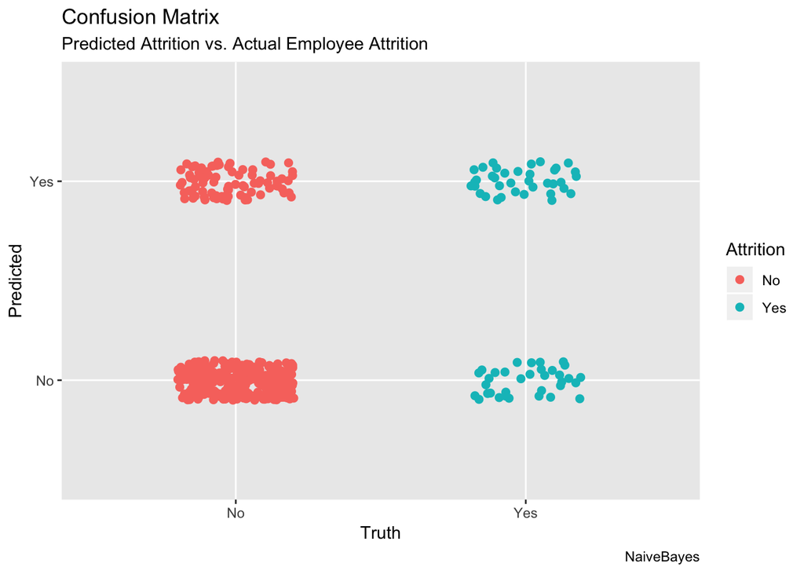

```r
#Show graph of clustered yes no prediction responses

ggplot(test, aes(Attrition, pred, color = Attrition)) +
  geom_jitter(width = 0.2, height = 0.1, size=2) +
  labs(title="Confusion Matrix",
       subtitle="Predicted Attrition vs. Actual Employee Attrition",
       y="Predicted",
       x="Truth",
       caption="NaiveBayes")
```

## Exploratory Data Analysis. Interpreting the probabilities.

In this section, we will examine the existing observations to understand trends amongst the samples.

```r
#Gender vs attrition.  Males tend to have a higher probability of attrition
Gender_prob <- subset(data.frame(NB_All$tables$Gender), Y=="Yes")
Gender_prob
```

```
##     Y Gender      Freq
## 2 Yes Female 0.3670886
## 4 Yes   Male 0.6329114
```

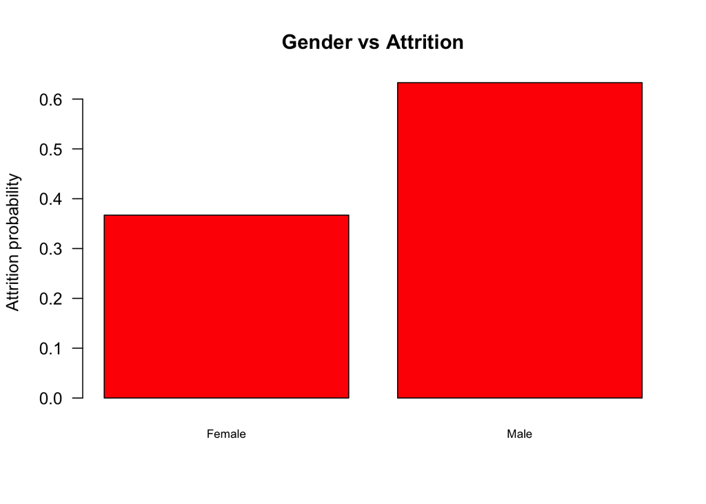

```r
barplot(Gender_prob$Freq, names.arg = Gender_prob$Gender, ylab="Attrition probability",main="Gender vs Attrition", cex.names=0.7,col="red",las=1)
```

Men tend to have a higher attrition rate than women (63% versus 37%).

```r
#Singles have a higher probability of attrition compared to married and divorced.
MaritalStat_prob <- subset(data.frame(NB_All$tables$MaritalStatus),Y=="Yes")
MaritalStat_prob
```

```
##     Y MaritalStatus      Freq
## 2 Yes      Divorced 0.1392405
## 4 Yes       Married 0.3544304
## 6 Yes        Single 0.5063291
```

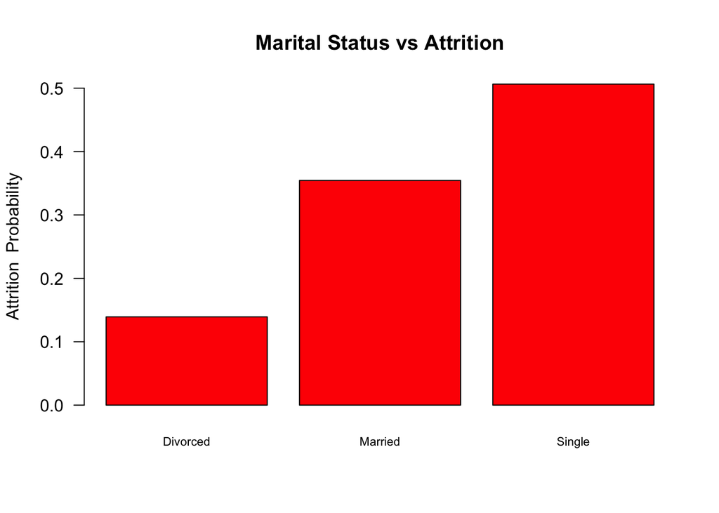

```r
barplot(MaritalStat_prob$Freq, names.arg = MaritalStat_prob$MaritalStatus, ylab="Attrition  Probability",main="Marital Status vs Attrition", cex.names=0.7,col="red",las=1)
```

Singles have a higher attrition rate at 51% than married (35%) or divorced individuals (14%).

```r
#Age.  Attrition probability is highest between 28 and 37 years of age.  The older the less likely to turn over.
Age_prob <- subset(data.frame(NB_All$tables$Agecat),Y=="Yes")
Age_prob
```

```
##     Y   Agecat       Freq
## 2 Yes Under_27 0.25431034
## 4 Yes    28-37 0.48706897
## 6 Yes    38-47 0.16379310
## 8 Yes      >48 0.09482759
```

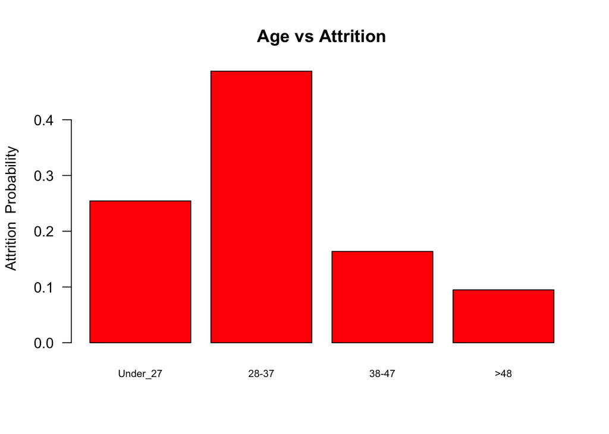

```r
barplot(Age_prob$Freq, names.arg = Age_prob$Agecat, ylab="Attrition  Probability",main="Age vs Attrition", cex.names=0.7,col="red",las=1)
```

There is less turnover for older individuals. The attrition rate is highest for those between ages 28 and 37.

```r
#Age.  Working Years vs Attrition.  The more work experience the less likely to turn over.
WorkYears_prob <- subset(data.frame(NB_All$tables$TotalWorkingYears),Y=="Yes")
WorkYears_prob
```

```
##     Y TotalWorkingYears       Freq
## 2 Yes      Less_than_10 0.66808511
## 4 Yes          11_to_20 0.26382979
## 6 Yes          21_to_30 0.05531915
## 8 Yes             Gt_30 0.01276596
```

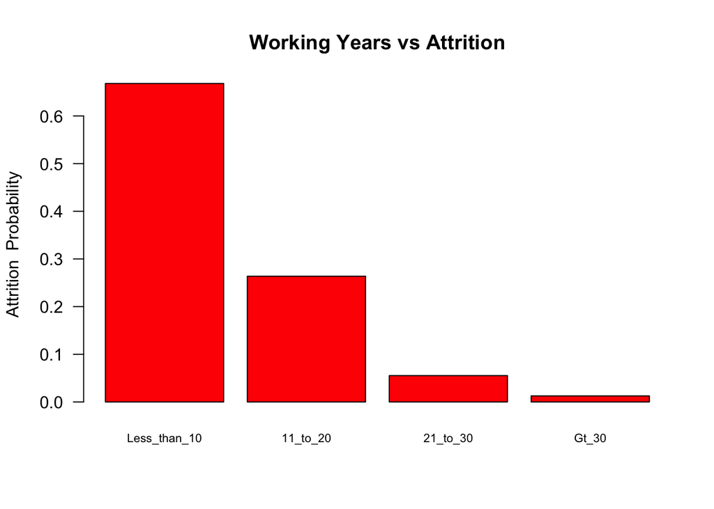

```r
barplot(WorkYears_prob$Freq, names.arg = WorkYears_prob$TotalWorkingYears, ylab="Attrition  Probability",main="Working Years vs Attrition", cex.names=0.7,col="red",las=1)
```

Similarly to age, those with less than 10 years of working experience have a much higher attrition rate than those with 11-20, 20-30, or more than 30 (67%, 26%, 6%, 1%, respectively).

```r
#Income vs Attrition.  The lower the income level the higher the probability of attrition
MontlyI_prob <- subset(data.frame(NB_All$tables$MonthlyIncome),Y=="Yes")
MontlyI_prob
```

```
##     Y MonthlyIncome       Freq
## 2 Yes   Under_5,000 0.68776371
## 4 Yes  Under_10,000 0.20675105
## 6 Yes  Under_15,000 0.08438819
## 8 Yes  Under_20,000 0.02109705
```

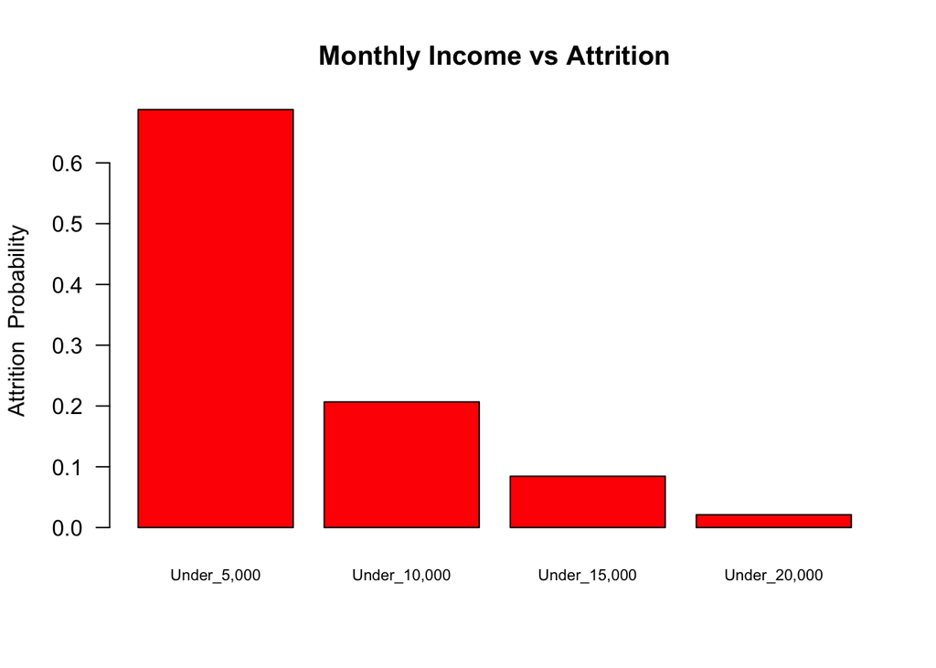

```r
barplot(MontlyI_prob$Freq, names.arg = MontlyI_prob$MonthlyIncome, ylab="Attrition  Probability",main="Monthly Income vs Attrition", cex.names=0.7,col="red",las=1)
```

In addition to age and experience, income has a similar relationship were attrition is much higher for employees who earn less. For those who make less than $5,000, the attrition rate is 69%. For those who earn 5,000-10,000, 10,000-15,000, and greater than 15,000 a month have rates of 21%, 8%, and 2%, respectively.

```r
#Salary hike vs Attrition.  The lower the hike the higher the probability of attrition
SalaryH_prob <- subset(data.frame(NB_All$tables$PercentSalaryHike),Y=="Yes")
SalaryH_prob
```

```
##     Y PercentSalaryHike      Freq
## 2 Yes     Less_than_15% 0.5593220
## 4 Yes     Less_than_20% 0.2881356
## 6 Yes  Greater_than_20% 0.1525424
```

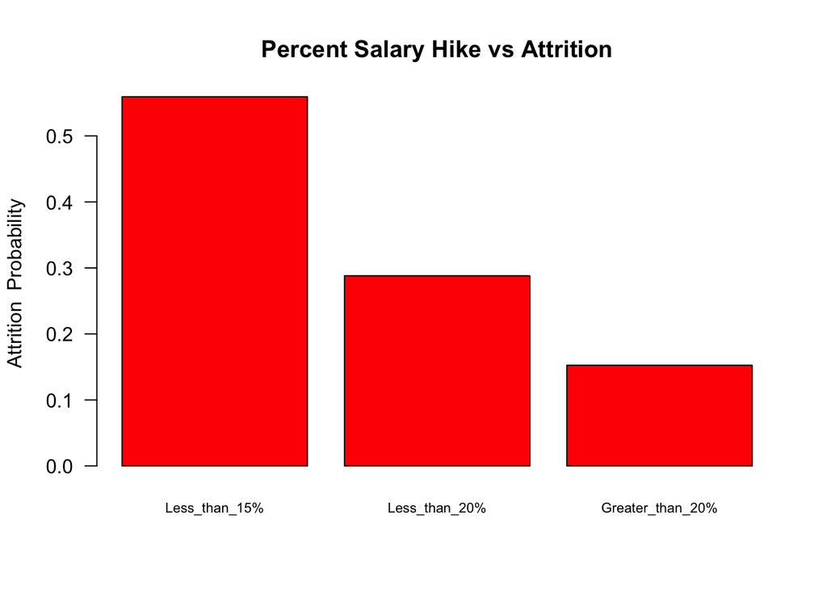

```r
barplot(SalaryH_prob$Freq, names.arg = SalaryH_prob$PercentSalaryHike, ylab="Attrition  Probability",main="Percent Salary Hike vs Attrition", cex.names=0.7,col="red",las=1)
```

Those who receive less of a proportional increase in salary also have a higher attrition rate. For raises that are 15% or less, there is a 56% attrition rate, versus 29% for 15-20% and 15% for a 20+% raise.

```r
#stock Option Levels vs attrition.  The lower the options the higher the attrition
StockO_prob <- subset(data.frame(NB_All$tables$StockOptionLevel),Y=="Yes")
StockO_prob
```

```
##     Y StockOptionLevel       Freq
## 2 Yes             High 0.06329114
## 4 Yes              Low 0.23628692
## 6 Yes           Medium 0.05063291
## 8 Yes             None 0.64978903
```

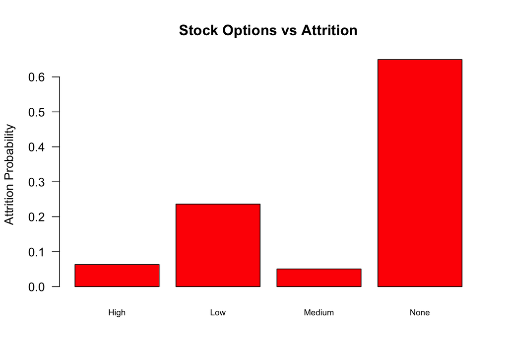

```r
barplot(StockO_prob$Freq, names.arg = StockO_prob$StockOptionLevel, ylab="Attrition Probability",main="Stock Options vs Attrition", cex.names=0.7,col="red",las=1)
```

Those without stock options have the highest attrition frequency at 65%.

```r
#Attrition vs Opportunity to travel.  If you can travel, the opportunity to travel shows a lower probability of attrition.
BusTrav_prob <- subset(data.frame(NB_All$tables$BusinessTravel), Y=="Yes")
BusTrav_prob
```

```
##     Y    BusinessTravel       Freq
## 2 Yes        Non-Travel 0.05063291
## 4 Yes Travel_Frequently 0.29113924
## 6 Yes     Travel_Rarely 0.65822785
```

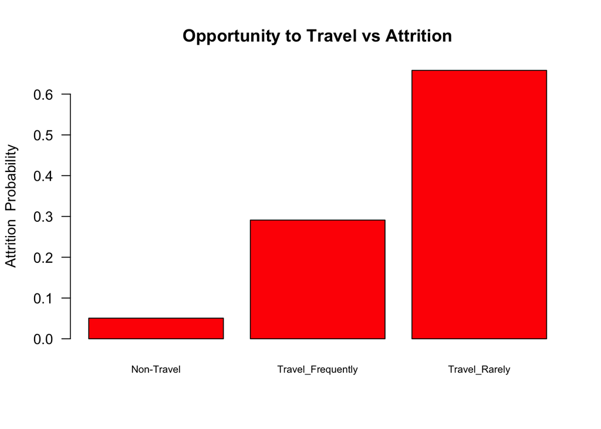

```r
barplot(BusTrav_prob$Freq, names.arg = BusTrav_prob$BusinessTravel, ylab="Attrition  Probability",main="Opportunity to Travel vs Attrition", cex.names=0.7,col="red",las=1)
```

Employees who do not have the option to travel have a very low attrition rate of 5%. For those who can travel, those that travel rarely have a much higher attrition rate than those who do travel (66% versus 29%).

```r
#Naive Bayes: Attrition vs Education. The higher level of education, the lower probability of attrition
Education_prob <- subset(data.frame(NB_All$tables$Education), Y=="Yes")
Education_prob
```

```
##      Y     Education       Freq
## 2  Yes      Bachelor 0.41772152
## 4  Yes Below_College 0.13080169
## 6  Yes       College 0.18565401
## 8  Yes        Doctor 0.02109705
## 10 Yes        Master 0.24472574
```

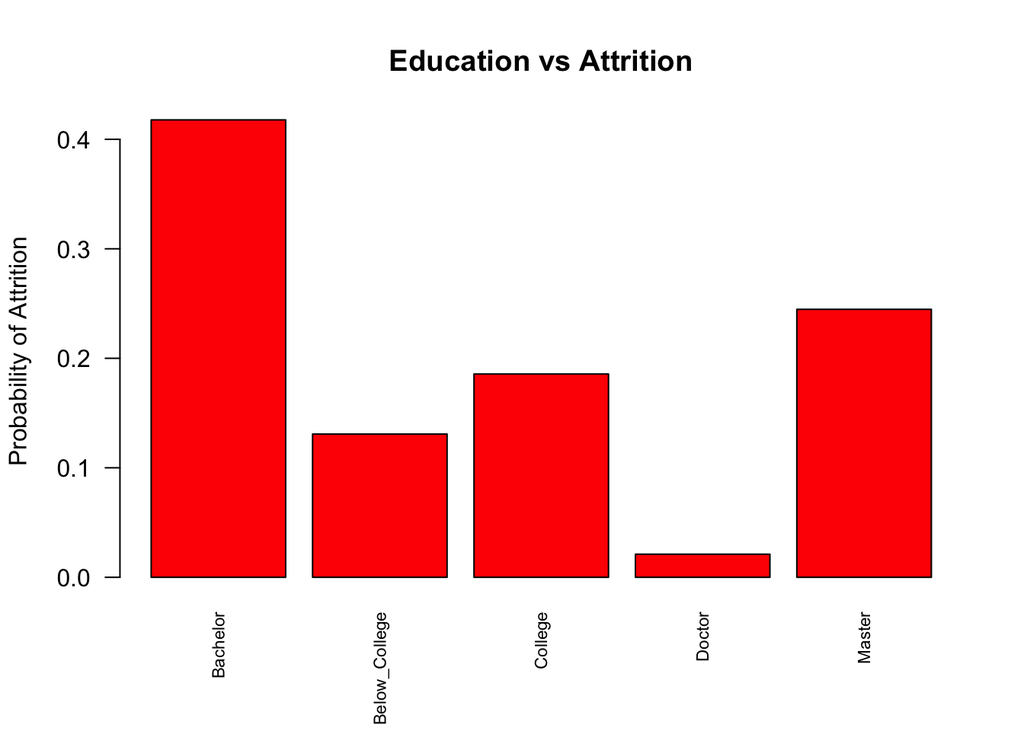

```r
barplot(Education_prob$Freq ,names.arg=Education_prob$Education,ylab="Probability of Attrition",main="Education vs Attrition", cex.names=0.7,col="red",las=2)
```

Those with bachelor’s, master’s, and college degrees have the highest attrition rates at 42%, 24%, and 19%. Those with doctorate’s and no college degrees have lower rates at 2% and 13%. Since there is no sequential trend, this suggests that there are factors correlated to education that also affect attrition.

```r
#Department vs probability of attrition.  Technical field tend to have a higher probability of attrition.  Human resources have a low probability of attrition in comparison.
Depart_prob <- subset(data.frame(NB_All$tables$Department),Y=="Yes")
Depart_prob
```

```
##     Y             Department       Freq
## 2 Yes        Human Resources 0.05063291
## 4 Yes Research & Development 0.56118143
## 6 Yes                  Sales 0.38818565
```

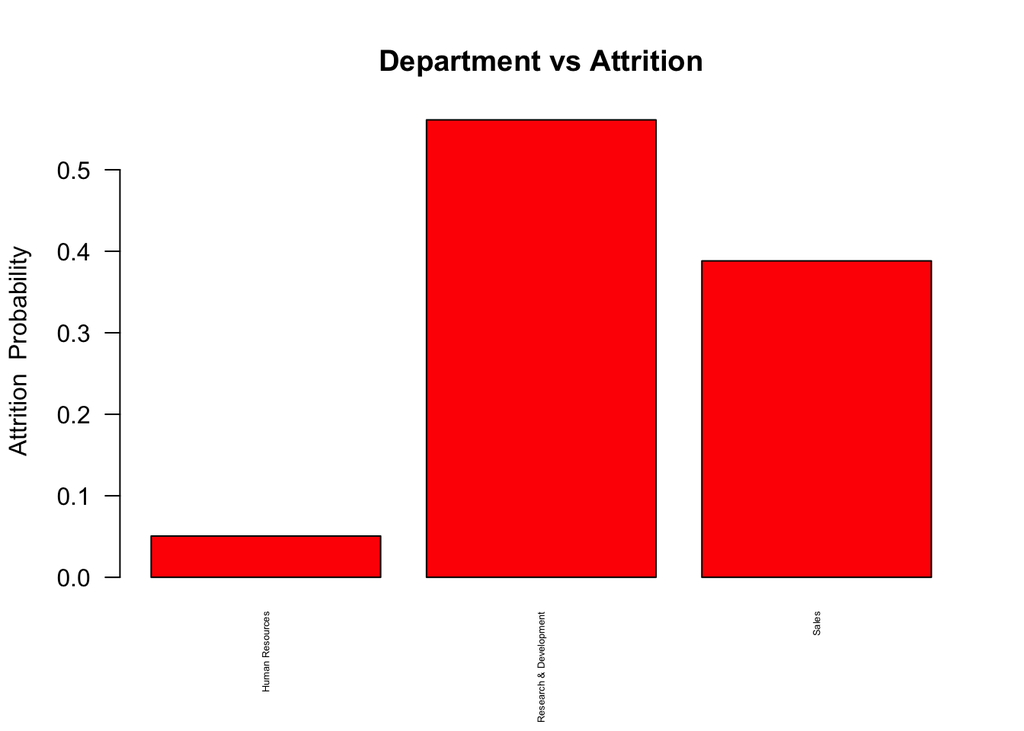

```r
barplot(Depart_prob$Freq, names.arg = Depart_prob$Department, ylab="Attrition  Probability",main="Department vs Attrition", cex.names=0.4,col="red",las=2)
```

Research & Development employees have the highest attrition at 56%, followed by sales at 39%, then HR at 5%.

```r
#Job Involvment.  High degrees of job involvment such as those in technical field have a highe probability of attrition. However, if you are a decision maker such as a Chief Data Scientist very high involvment have low probabilities of attrition.
JobI_prob <- subset(data.frame(NB_All$tables$JobInvolvement), Y=="Yes")
JobI_prob
```

```
##     Y JobInvolvement       Freq
## 2 Yes           High 0.52742616
## 4 Yes            Low 0.11814346
## 6 Yes         Medium 0.29957806
## 8 Yes      Very_High 0.05485232
```

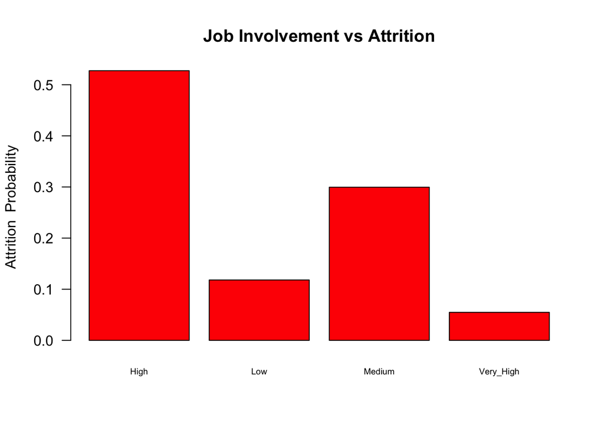

```r
barplot(JobI_prob$Freq, names.arg = JobI_prob$JobInvolvement, ylab="Attrition  Probability",main="Job Involvement vs Attrition", cex.names=0.6,col="red",las=1)
```

High and medium job involvement have higher attrition rates at 53% and 30%, while very high involvement has a rate of 5% and low involvement has a rate of 12%. This could be due to the nature of the ranking system (more likely to avoid extreme rankings) or another correlated factor.

```r
#Work life balance. On surveys 'Better' may be and indicator of employee unhappiness. A mark of 'Better' has a high probability of attrition
LifeBalance_prob <- subset(data.frame(NB_All$tables$WorkLifeBalance),Y=="Yes")
LifeBalance_prob
```

```
##     Y WorkLifeBalance      Freq
## 2 Yes             Bad 0.1054852
## 4 Yes            Best 0.1139241
## 6 Yes          Better 0.5358650
## 8 Yes            Good 0.2447257
```

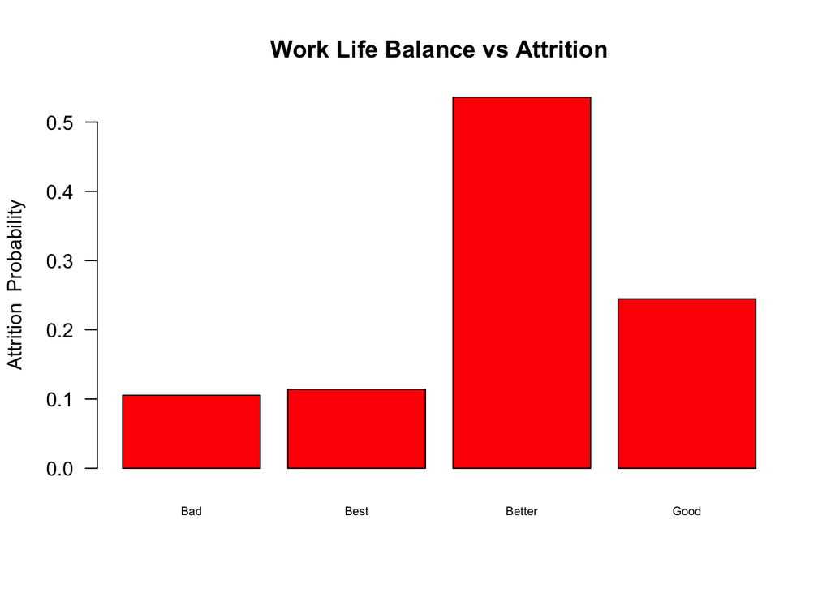

```r
barplot(LifeBalance_prob$Freq, names.arg = LifeBalance_prob$WorkLifeBalance, ylab="Attrition  Probability",main="Work Life Balance vs Attrition", cex.names=0.6,col="red",las=1)
```

Those with “better” and “good” work life balances counterintuitively have higher attrition rates of 54% and 24%. The two more extreme rankings of “bad” and “best” are 10% and 11% respectively.

## Evaluating the correlations. Logistic Regression.

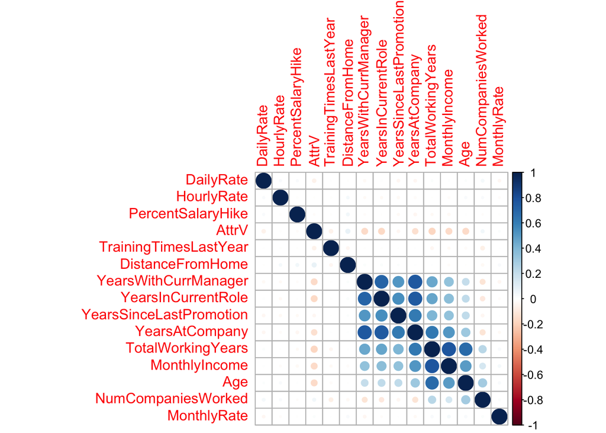

```r
# Create a new binary variable for attrition
attrition$AttrV<-ifelse(attrition$Attrition=="Yes",1,0)
#create subset of Continous Variables
attritionInt <- attrition[,c(1,4,6,11,17:19,21,25,26,28:31,32)]
#create correlation matix for Continous Variables
corAttInt <- cor(attritionInt)
#plot correlation matrix
corrplot(corAttInt, order='AOE', method='circle')
```

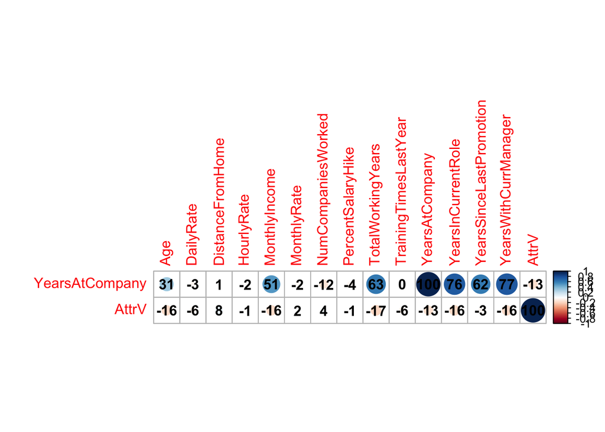

```r
#create smaller matrix focused on AttrV variable / Plot Matrix
corAttrVInt <- corAttInt[c(11,15),]
corrplot(corAttrVInt, method='circle',addCoef.col ='black', addCoefasPercent = TRUE )
```

The strongest correlations between predictors occurs for the many variatons of working experience predictors (i.e. years with current manager, years in current role, years since last promotion, years at the company, total working years, monthly income, and age). Due to these correlations, these variables are likely to provide little additional insight when used in an additive model framework such as logistic regression (which we will implement later in this analysis).

## Preliminary Correlation Tests for for Ordinal Variables

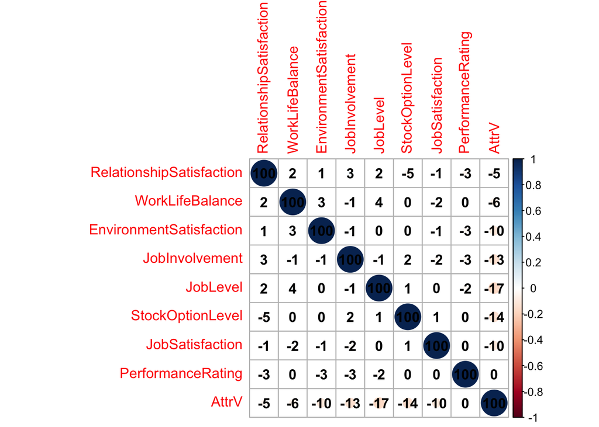

```r
#create subset of Ordinal Variables
attritionOrd <- attrition[,c(9,12,13,15,22:24,27,32)]
#create correlation matix for Ordinal Variables
corAttOrd <- cor(attritionOrd)
#plot correlation matrix
corrplot(corAttOrd,order='AOE', method='circle',addCoef.col ='black', addCoefasPercent = TRUE )
```

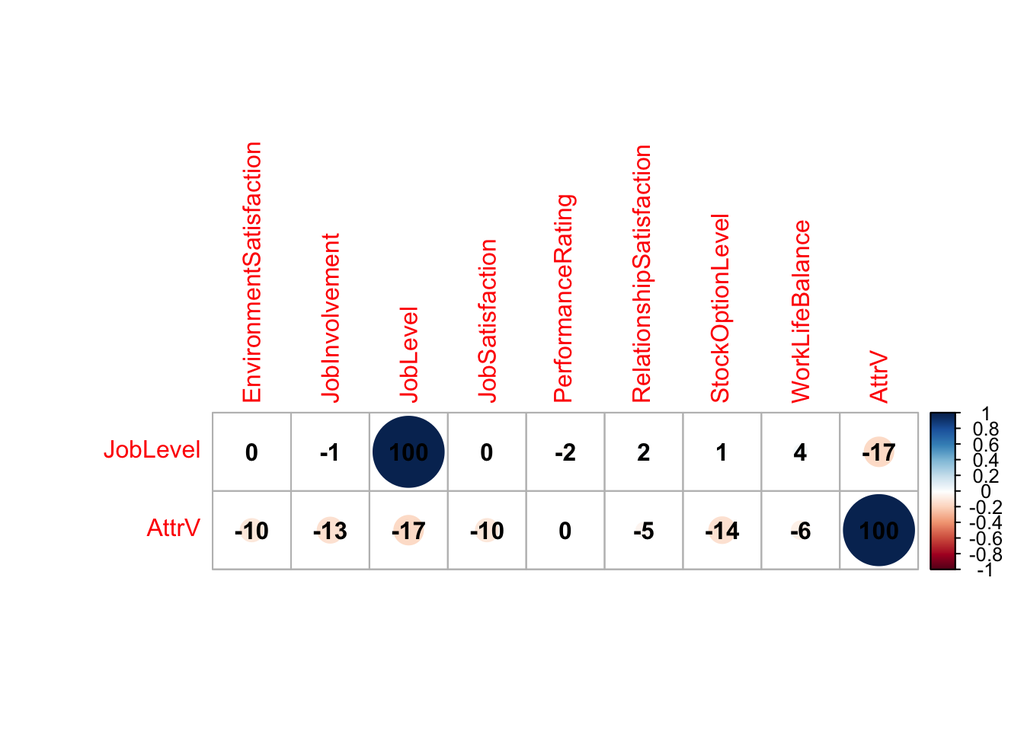

```r
#create smaller matrix focused on AttrV variable / Plot Matrix
corAttrVOrd <- corAttOrd[c(3,9),]
corrplot(corAttrVOrd, method='circle',addCoef.col ='black', addCoefasPercent = TRUE )
```

There appear to be no correlations of concern for the ordinal variables in question.

## Preliminary t-tests for significance of Ordinal and Continous Variables.

Each variable was tested for significance in a singular comparison with attrition rate.

| Category | t-value | p-value |
| --- | --- | --- |
| TotalWorkingYears | 6.65 | < .0001 |
| JobLevel | 6.57 | < .0001 |
| YearsInCurrentRole | 6.23 | < .0001 |
| MonthlyIncome | 6.20 | < .0001 |
| Age | 6.18 | < .0001 |
| YearsWithCurrManager | 6.06 | < .0001 |
| StockOptionLevel | 5.30 | < .0001 |
| YearsAtCompany | 5.20 | < .0001 |
| JobInvolvement | 5.02 | < .0001 |
| JobSatisfaction | 3.99 | < .0001 |
| EnvironmentSatisfaction | 3.98 | < .0001 |
| DistanceFromHome | 2.99 | .0027 |
| WorkLifeBalance | 2.45 | .0142 |
| TrainingTimesLastYear | 2.28 | .0225 |
| DailyRate | 2.17 | .0299 |
| RelationshipSatisfaction | 1.76 | .0787 |
| NumCompaniesWorked | 1.67 | .0955 |
| YearsSinceLastPromotion | 1.27 | .2058 |
| Education | 1.20 | .2293 |
| MonthlyRate | .58 | .5611 |
| PercentSalaryHike | .52 | .6056 |
| HourlyRate | .26 | .7931 |

## Preliminary Correlation Tests for for Nominal Variables

| Category | **r** | F-value | *p*-value |
| --- | --- | --- | --- |
| Over Time | n/a | 94.66 | < .0001 |
| MaritalStatus | .176 | 23.78 | < .0001 |
| BusinessTravel | .126 | 12.27 | < .0001 |
| JobRole | .243 | 11.38 | < .0001 |
| Department | .084 | 5.43 | .0045 |
| Educationfield | .105 | 3.23 | .0066 |
| Education | .044 | 1.45 | .2290 |
| Gender | n/a | 1.28 | .2591 |

```r
#create  model dataset with chosen variables
#attritionMdl <- attrition[,c(1,3,5,6,8,9,13:17,20,24,25,28,29,32),drop=FALSE]
#attritionMdl$AttrV <- factor(attritionMdl$AttrV, levels = c(0, 1))
#create full dataset with scrubbed data
attritionFull <- as.data.frame(attrition)
attritionFull$AttrV <-ifelse(attrition$Attrition=="Yes",1,0)
```

## Creating a Training Model

```r
#create training data sample size at 80% of Dataset set.seed to ensure same rows are chosen
smpSize = floor(.80*nrow(attritionFull))
set.seed(123)
trainSmp = sample(seq_len(nrow(attritionFull)),size = smpSize)
trainAttr =attritionFull[trainSmp,]
testAttr=attritionFull[-trainSmp,]
trainSmpF = sample(seq_len(nrow(attritionFull)),size = smpSize)
trainAttrF =attritionFull[trainSmp,-2]
testAttrF=attritionFull[-trainSmp,]
```

## Model Selection

The response variable of interest, Attrition, is binary. In order to determine what leads to attrition, we decided to use a logistic regression model, a classification regression method for binary outputs. We assume that there is a linear, additive relationship between the predictors and the natural log odds of attrition rate.

## Stepwise Regression Variable Selection

In order to determine which factors have a higher association with attrition rate, two systematic approaches were used: Forward and Backward stepwise variable selection. In both cases, the three variables selected are Marital Status, Overtime, and Total Working Years. The importance of these factors will be further assessed in the building of a logistic regression classification model.

```r
# Fit the full model
StpFor<- regsubsets(AttrV~.,data=trainAttrF,method="forward",nbest=1, nvmax=3)
topFor<-coef(StpFor,3)
topFor
```

```
##         (Intercept) MaritalStatusSingle         OverTimeYes
##         0.147824656         0.126665157         0.220728272
##   TotalWorkingYears
##        -0.008149558
```

```r
StpBack <- regsubsets(AttrV~.,data=trainAttrF,method="backward",nbest=1, nvmax=3)
topBack<-coef(StpBack,3)
topBack
```

```
##         (Intercept) MaritalStatusSingle         OverTimeYes
##         0.147824656         0.126665157         0.220728272
##   TotalWorkingYears
##        -0.008149558
```

## Train Logistic Regression Model

```r
#create logitFull
logitFull <- glm(AttrV ~ YearsAtCompany + BusinessTravel +  Department + EducationField + Gender +  JobRole + MaritalStatus + Age + HourlyRate + DailyRate + MonthlyRate + MonthlyIncome + DistanceFromHome + Education + EnvironmentSatisfaction + JobInvolvement + JobLevel + JobSatisfaction + NumCompaniesWorked + PercentSalaryHike + PerformanceRating + RelationshipSatisfaction + StockOptionLevel + TotalWorkingYears + TrainingTimesLastYear + WorkLifeBalance + YearsInCurrentRole + YearsSinceLastPromotion + YearsWithCurrManager + OverTime, family = binomial, data = trainAttrF)
s<-summary(logitFull)
a<-anova(logitFull, test="Chisq")
cor(trainAttr[,c(31,30,29,28)])
```

```
##                         YearsWithCurrManager YearsSinceLastPromotion
## YearsWithCurrManager               1.0000000               0.5034368
## YearsSinceLastPromotion            0.5034368               1.0000000
## YearsInCurrentRole                 0.7047477               0.5729467
## YearsAtCompany                     0.7639706               0.6284837
##                         YearsInCurrentRole YearsAtCompany
## YearsWithCurrManager             0.7047477      0.7639706
## YearsSinceLastPromotion          0.5729467      0.6284837
## YearsInCurrentRole               1.0000000      0.7673168
## YearsAtCompany                   0.7673168      1.0000000
```

```r
#remove insignificant terms based on p-values and chi-squared tests & correlated terms
logitMod<-glm(AttrV~OverTime+MaritalStatus+TotalWorkingYears+BusinessTravel+DistanceFromHome
              +EnvironmentSatisfaction+JobInvolvement+JobRole+JobSatisfaction+MaritalStatus
              +NumCompaniesWorked+TotalWorkingYears+OverTime+
              RelationshipSatisfaction,data=trainAttrF, family=binomial(link="logit"))
summary(logitMod)
```

```
##
## Call:
## glm(formula = AttrV ~ OverTime + MaritalStatus + TotalWorkingYears +
##     BusinessTravel + DistanceFromHome + EnvironmentSatisfaction +
##     JobInvolvement + JobRole + JobSatisfaction + MaritalStatus +
##     NumCompaniesWorked + TotalWorkingYears + OverTime + RelationshipSatisfaction,
##     family = binomial(link = "logit"), data = trainAttrF)
##
## Deviance Residuals:
##     Min       1Q   Median       3Q      Max
## -1.7837  -0.5292  -0.3106  -0.1445   3.7263
##
## Coefficients:
##                                 Estimate Std. Error z value Pr(>|z|)
## (Intercept)                     -1.46812    0.83987  -1.748  0.08046 .
## OverTimeYes                      1.94577    0.20161   9.651  < 2e-16 ***
## MaritalStatusMarried             0.24755    0.27394   0.904  0.36616
## MaritalStatusSingle              1.23963    0.27646   4.484 7.33e-06 ***
## TotalWorkingYears               -0.07840    0.01941  -4.040 5.34e-05 ***
## BusinessTravelTravel_Frequently  1.93377    0.46670   4.144 3.42e-05 ***
## BusinessTravelTravel_Rarely      1.14820    0.43472   2.641  0.00826 **
## DistanceFromHome                 0.04787    0.01133   4.226 2.38e-05 ***
## EnvironmentSatisfaction         -0.34912    0.08628  -4.046 5.20e-05 ***
## JobInvolvement                  -0.36692    0.13170  -2.786  0.00534 **
## JobRoleHuman Resources           1.13781    0.60071   1.894  0.05821 .
## JobRoleLaboratory Technician     1.16676    0.45770   2.549  0.01080 *
## JobRoleManager                   0.38610    0.74937   0.515  0.60639
## JobRoleManufacturing Director   -0.19995    0.54997  -0.364  0.71618
## JobRoleResearch Director        -0.64905    0.88652  -0.732  0.46409
## JobRoleResearch Scientist        0.38978    0.46454   0.839  0.40144
## JobRoleSales Executive           0.83853    0.44549   1.882  0.05980 .
## JobRoleSales Representative      1.67914    0.52742   3.184  0.00145 **
## JobSatisfaction                 -0.40702    0.08517  -4.779 1.76e-06 ***
## NumCompaniesWorked               0.12113    0.03861   3.137  0.00170 **
## RelationshipSatisfaction        -0.20757    0.08694  -2.387  0.01697 *
## ---
## Signif. codes:  0 '***' 0.001 '**' 0.01 '*' 0.05 '.' 0.1 ' ' 1
##
## (Dispersion parameter for binomial family taken to be 1)
##
##     Null deviance: 1033.57  on 1175  degrees of freedom
## Residual deviance:  750.51  on 1155  degrees of freedom
## AIC: 792.51
##
## Number of Fisher Scoring iterations: 6
```

```r
anova(logitMod, test="Chisq")
```

```
## Analysis of Deviance Table
##
## Model: binomial, link: logit
##
## Response: AttrV
##
## Terms added sequentially (first to last)
##
##
##                          Df Deviance Resid. Df Resid. Dev  Pr(>Chi)
## NULL                                      1175    1033.57
## OverTime                  1   75.560      1174     958.01 < 2.2e-16 ***
## MaritalStatus             2   38.627      1172     919.39 4.095e-09 ***
## TotalWorkingYears         1   42.148      1171     877.24 8.462e-11 ***
## BusinessTravel            2   19.005      1169     858.23 7.467e-05 ***
## DistanceFromHome          1   15.539      1168     842.69 8.082e-05 ***
## EnvironmentSatisfaction   1   18.202      1167     824.49 1.987e-05 ***
## JobInvolvement            1    7.680      1166     816.81  0.005585 **
## JobRole                   8   28.864      1158     787.95  0.000335 ***
## JobSatisfaction           1   23.200      1157     764.75 1.460e-06 ***
## NumCompaniesWorked        1    8.514      1156     756.23  0.003524 **
## RelationshipSatisfaction  1    5.720      1155     750.51  0.016771 *
## ---
## Signif. codes:  0 '***' 0.001 '**' 0.01 '*' 0.05 '.' 0.1 ' ' 1
```

## Visualizing Working Years

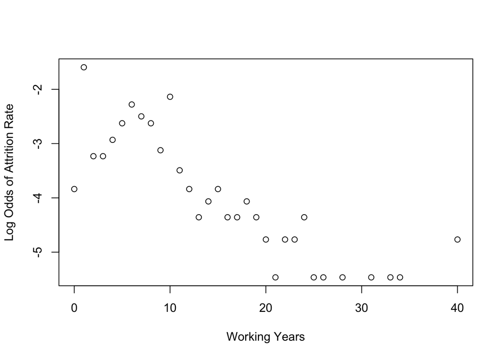

```r
by.t<-attritionFull %>% group_by(TotalWorkingYears) %>% summarize(attt=sum(AttrV))
prop.t<-by.t$attt/sum(by.t$attt)
plot(by.t$TotalWorkingYears,logit(prop.t), xlab="Working Years", ylab="Log Odds of Attrition Rate")
```

## Testing the Model

```r
#testing Data
pred <- predict(logitMod, newdata = testAttr, type = "response")

# Recode factors
y_pred_num <- ifelse(pred > 0.5, 1, 0)
y_pred <- factor(y_pred_num, levels=c(0, 1))
y_act <- testAttr$AttrV
# Accuracy
mean(y_pred == y_act)
```

```
## [1] 0.8809524
```

```r
predF <- predict(logitFull, newdata = testAttrF, type = "response")

# Recode factors
y_pred_numF <- ifelse(predF > 0.5, 1, 0)
y_predF <- factor(y_pred_numF, levels=c(0, 1))
y_actF <- testAttrF$AttrV
# Accuracy
mean(y_predF == y_actF)
```

```
## [1] 0.8809524
```

The logistic regression model based on 11 variables had a 88% accurate classification rate against the test data. While overtime eligibility, marriage status, and years in the workforce are key indicators, there are many factors that lead to attrition in a company.

## Other Job Role Trends

While attrition is a great concern for companies, it is also important for management to understand the working culture that they create. Below we will discuss some key employee-related findings.

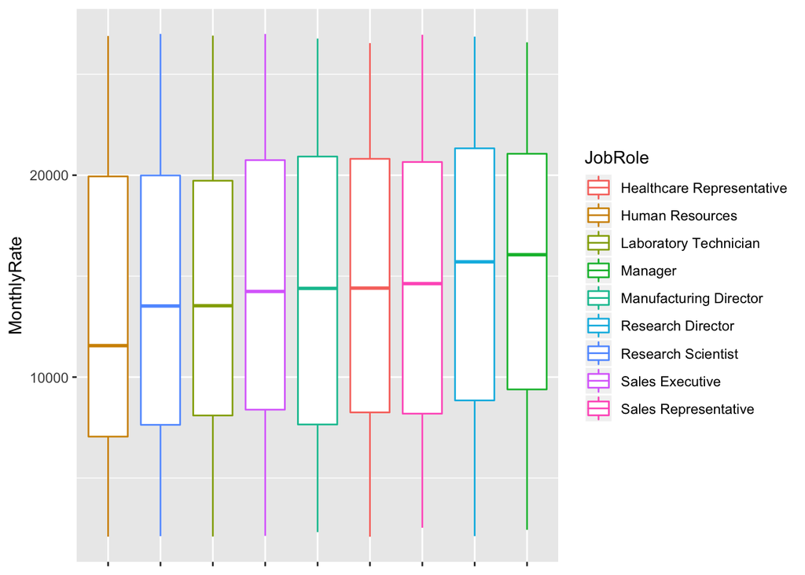

```r
ggplot(attritionFull, aes(x=reorder(JobRole, MonthlyRate, FUN = median), y=MonthlyRate, color=JobRole)) + geom_boxplot()+theme(
      axis.text.x=element_blank(),axis.title.x = element_blank())
```

The monthly rate appears to be distributed evenly across all job roles; no job role has a significantly higher monthly rate than the others.

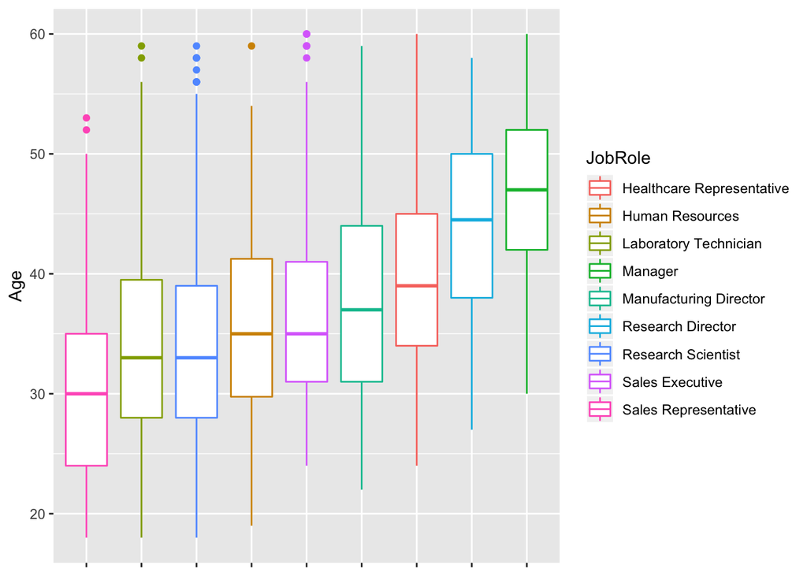

```r
ggplot(attritionFull, aes(x=reorder(JobRole, Age, FUN=median),y=Age, color=JobRole))+geom_boxplot()+theme(
        axis.text.x=element_blank(), axis.title.x = element_blank())
```

The distribution of ages differs across job roles. Sales Representatives tend to be the youngest, while managers and directors tend to be older. Healthcare representatives tend to be older than manufacturing directors, which is interesting considering it is not a traditional management role (management roles tend to be associated with experience and therefore age).

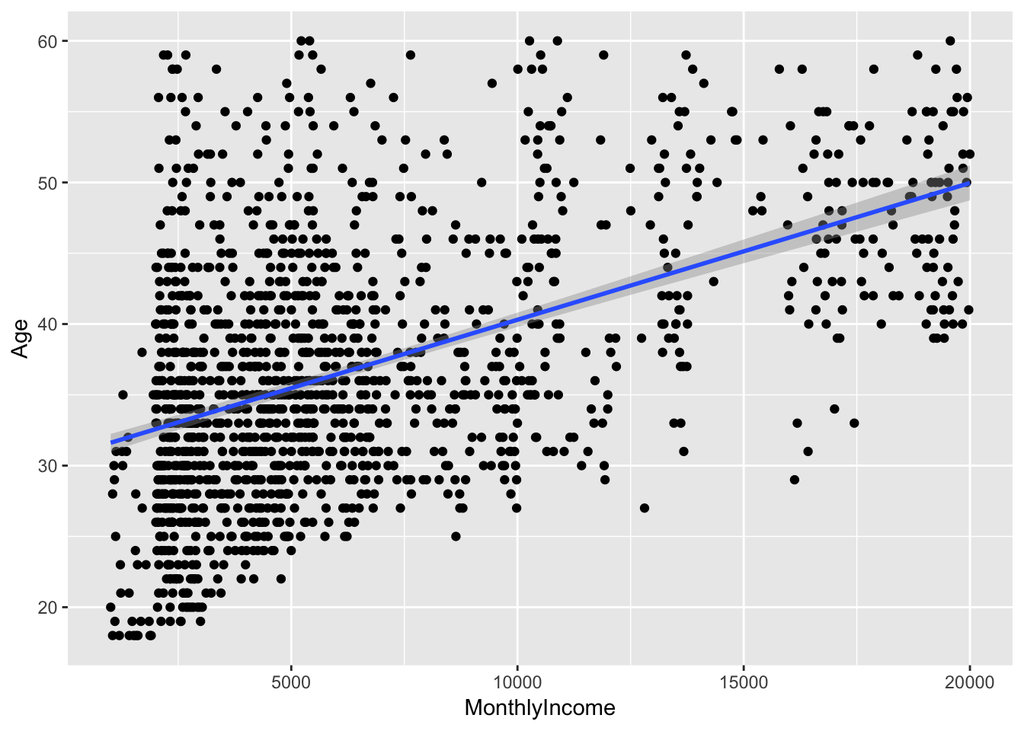

```r
ggplot(attritionFull, aes(x=MonthlyIncome,y=Age))+geom_point()+geom_smooth(method=lm)
```

Not many young employees have high monthly incomes, but low monthly incomes are associated with a wide range of ages.

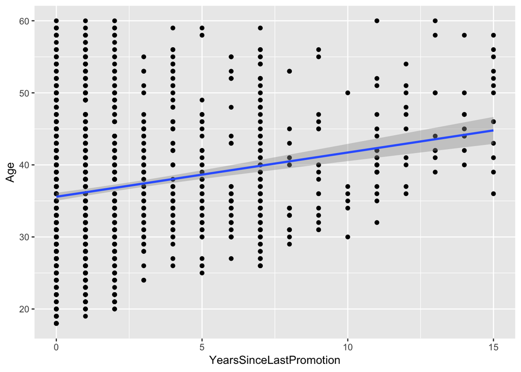

```r
ggplot(attritionFull, aes(x=YearsSinceLastPromotion, y=Age))+geom_point()+geom_smooth(method=lm)
```

Older employees tend to be promoted less often, while younger employees tend to more actively “climb the ladder”.

## Conclusions from Analysis

Through exploration into attrition contributors, it is clear that many factors are correlated and influenced by a number of externalities. Not only are employees affected by personal circumstances (marriage status, work life balance, age), but internal as well (job role, salary increases, overtime eligibility). Each factor conveys a unique relationship with employees and their behavior, and there are a number of techniques available to gain an understanding of the underlying relationships.